# UPRAK MPDW

Irsyad Parama

2024-10-10

# Ujian Praktek MPDW

Nama : Irsyad Parama Dwiputra

NIIM : G1401221101

Bilangan Acak : 31

```r
library(ggplot2)
library(tsibble)
library(tseries)
library(MASS)
library(forecast)
library(TSA)
library(TTR)
library(aTSA)
library(graphics)
library(readxl)
```

```r
data <- read_excel("C:/Users/DSITD/Downloads/dataset_ujian_praktikum.xlsx", sheet = "Sheet2")
#View(data)
```

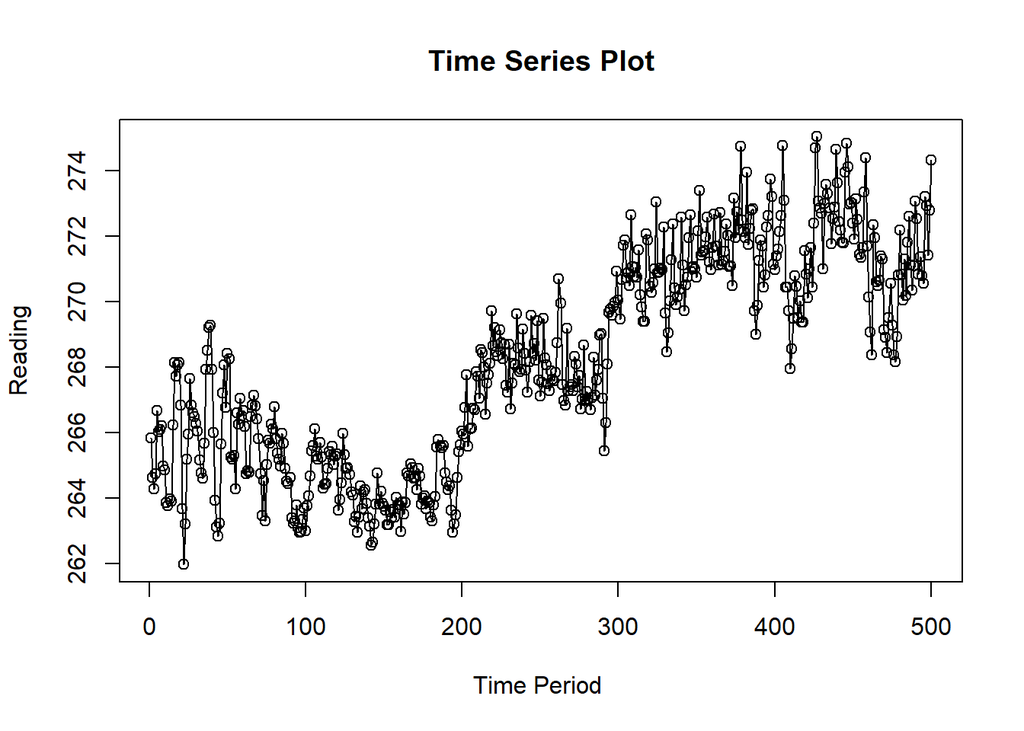

```r
ts.plot(data, xlab="Time Period ", ylab="Reading",
        main = "Time Series Plot")
points(data)
```

```r
data.ts <- ts(data$Penambahan)
```

```r
training_ma <- data[1:400,]
testing_ma <- data[401:01,]
train_ma.ts <- ts(training_ma$Penambahan)
test_ma.ts <- ts(testing_ma$Penambahan)
```

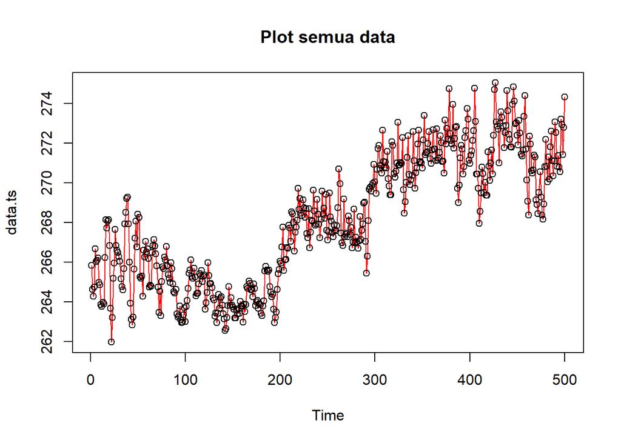

```r
#eksplorasi keseluruhan data
plot(data.ts, col="red",main="Plot semua data")
points(data.ts)
```

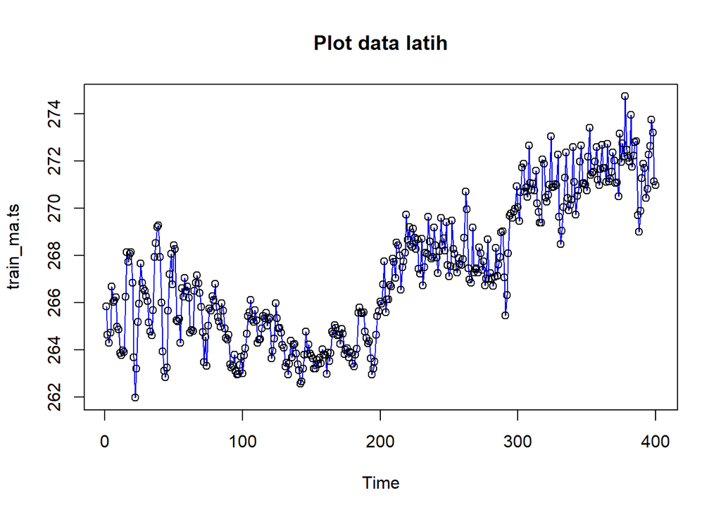

```r
#eksplorasi data latih
plot(train_ma.ts, col="blue",main="Plot data latih")
points(train_ma.ts)
```

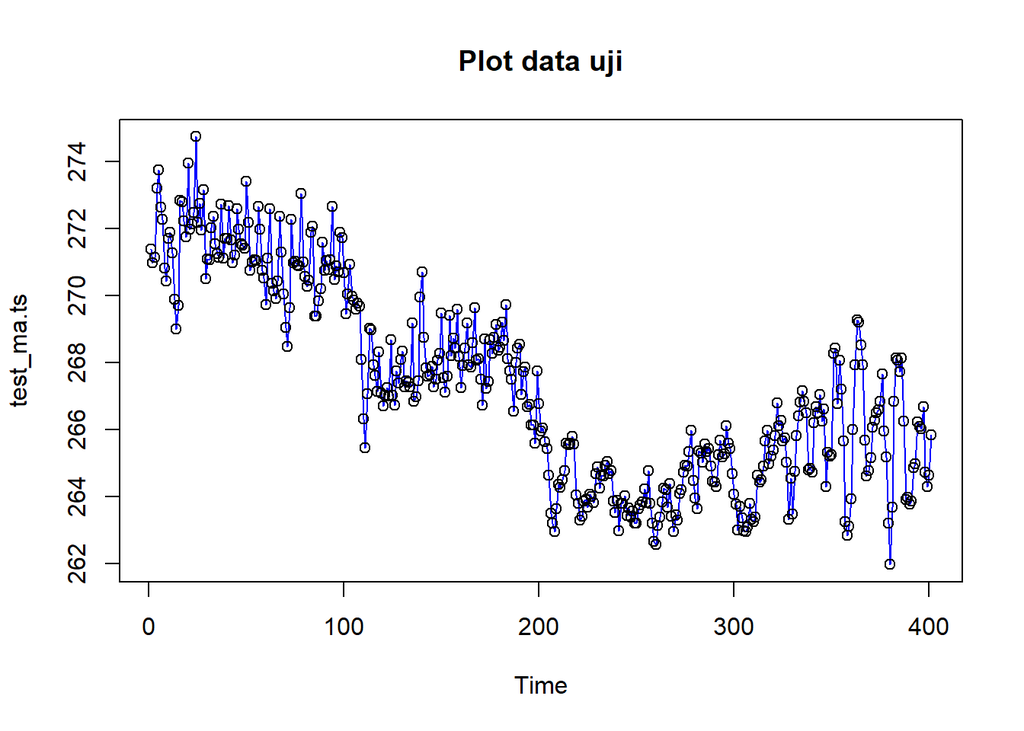

```r
#eksplorasi data uji
plot(test_ma.ts, col="blue",main="Plot data uji")
points(test_ma.ts)
```

```r
data.sma<-SMA(train_ma.ts, n=4)
data.sma
```

```
## Time Series:
## Start = 1
## End = 400
## Frequency = 1
##   [1]       NA       NA       NA 264.8750 265.0850 265.4325 265.8825 266.2525
##   [9] 265.8300 265.5400 264.9825 264.3725 264.1225 263.8850 264.4800 265.5700
##  [17] 266.5050 267.5425 268.0150 267.6900 266.6800 265.1600 263.9300 263.5175
##  [25] 264.0850 265.5050 266.4125 266.7650 266.8975 266.5525 266.3575 266.0000
##  [33] 265.5700 265.1550 265.0600 265.7525 266.6900 267.8350 268.7350 268.7325
##  [41] 268.1050 266.7875 265.2475 263.9775 263.2875 263.7200 264.7400 266.0450
##  [49] 266.9275 267.6200 267.8850 267.1800 266.7850 266.0050 265.0125 265.3525
##  [57] 265.6150 266.0475 266.6025 266.6200 266.6075 266.0325 265.6150 265.1425
##  [65] 265.2175 265.7425 266.3200 266.8250 266.8025 266.5475 265.9500 265.1175
##  [73] 264.6500 264.0250 264.0900 264.6600 264.9425 265.6800 265.9550 266.2150
##  [81] 266.2500 266.0275 265.7975 265.3425 265.3875 265.4600 265.3900 265.2725
```

[output cut: 39 more lines]

```r
data.ramal<-c(NA,data.sma)
data.ramal
```

```
##   [1]       NA       NA       NA       NA 264.8750 265.0850 265.4325 265.8825
##   [9] 266.2525 265.8300 265.5400 264.9825 264.3725 264.1225 263.8850 264.4800
##  [17] 265.5700 266.5050 267.5425 268.0150 267.6900 266.6800 265.1600 263.9300
##  [25] 263.5175 264.0850 265.5050 266.4125 266.7650 266.8975 266.5525 266.3575
##  [33] 266.0000 265.5700 265.1550 265.0600 265.7525 266.6900 267.8350 268.7350
##  [41] 268.7325 268.1050 266.7875 265.2475 263.9775 263.2875 263.7200 264.7400
##  [49] 266.0450 266.9275 267.6200 267.8850 267.1800 266.7850 266.0050 265.0125
##  [57] 265.3525 265.6150 266.0475 266.6025 266.6200 266.6075 266.0325 265.6150
##  [65] 265.1425 265.2175 265.7425 266.3200 266.8250 266.8025 266.5475 265.9500
##  [73] 265.1175 264.6500 264.0250 264.0900 264.6600 264.9425 265.6800 265.9550
##  [81] 266.2150 266.2500 266.0275 265.7975 265.3425 265.3875 265.4600 265.3900
##  [89] 265.2725 264.8850 264.6275 264.2450 263.9300 263.6500 263.4375 263.3625
##  [97] 263.2900 263.2075 263.1000 263.2550 263.2675 263.4650 263.6450 263.8900
## [105] 264.4975 264.9525 265.4625 265.6100 265.5475 265.5700 265.3550 265.1100
## [113] 264.9200 264.6100 264.5225 264.8050 265.0325 265.3150 265.3425 265.3075
```

[output cut: 36 more lines]

```r
data.gab<-cbind(aktual=c(train_ma.ts,rep(NA,24)),pemulusan=c(data.sma,rep(NA,24)),ramalan=c(data.ramal,rep(data.ramal[length(data.ramal)],23)))
data.gab
```

```
##        aktual pemulusan  ramalan
##   [1,] 265.84        NA       NA
##   [2,] 264.63        NA       NA
##   [3,] 264.29        NA       NA
##   [4,] 264.74  264.8750       NA
##   [5,] 266.68  265.0850 264.8750
##   [6,] 266.02  265.4325 265.0850
##   [7,] 266.09  265.8825 265.4325
##   [8,] 266.22  266.2525 265.8825
##   [9,] 264.99  265.8300 266.2525
##  [10,] 264.86  265.5400 265.8300
##  [11,] 263.86  264.9825 265.5400
##  [12,] 263.78  264.3725 264.9825
##  [13,] 263.99  264.1225 264.3725
##  [14,] 263.91  263.8850 264.1225
```

[output cut: 410 more lines]

```r
error_train.sma = train_ma.ts-data.ramal[1:length(train_ma.ts)]
SSE_train.sma = sum(error_train.sma[5:length(train_ma.ts)]^2)
MSE_train.sma = mean(error_train.sma[5:length(train_ma.ts)]^2)
MAPE_train.sma = mean(abs((error_train.sma[5:length(train_ma.ts)]/train_ma.ts[5:length(train_ma.ts)])*100))

akurasi_train.sma <- matrix(c(SSE_train.sma, MSE_train.sma, MAPE_train.sma))
row.names(akurasi_train.sma)<- c("SSE", "MSE", "MAPE")
colnames(akurasi_train.sma) <- c("Akurasi m = 4")
akurasi_train.sma
```

```
##      Akurasi m = 4
## SSE    576.6179875
## MSE      1.4561060
## MAPE     0.3426468
```

Dalam hal ini nilai MAPE data latih pada metode pemulusan SMA kurang dari 2%, nilai ini dapat dikategorikan sebagai nilai akurasi yang sangat baik. Selanjutnya dilakukan perhitungan nilai MAPE data uji pada metde pemulusan SMA.

```r
#Menghitung nilai keakuratan data uji
error_test.sma = test_ma.ts-data.gab[97:120,3]
```

```r
SSE_test.sma = sum(error_test.sma^2)
MSE_test.sma = mean(error_test.sma^2)
MAPE_test.sma = mean(abs((error_test.sma/test_ma.ts*100)))

akurasi_test.sma <- matrix(c(SSE_test.sma, MSE_test.sma, MAPE_test.sma))
row.names(akurasi_test.sma)<- c("SSE", "MSE", "MAPE")
colnames(akurasi_test.sma) <- c("Akurasi m = 4")
akurasi_test.sma
```

```
##      Akurasi m = 4
## SSE    6987.536287
## MSE      17.425278
## MAPE      1.210219
```

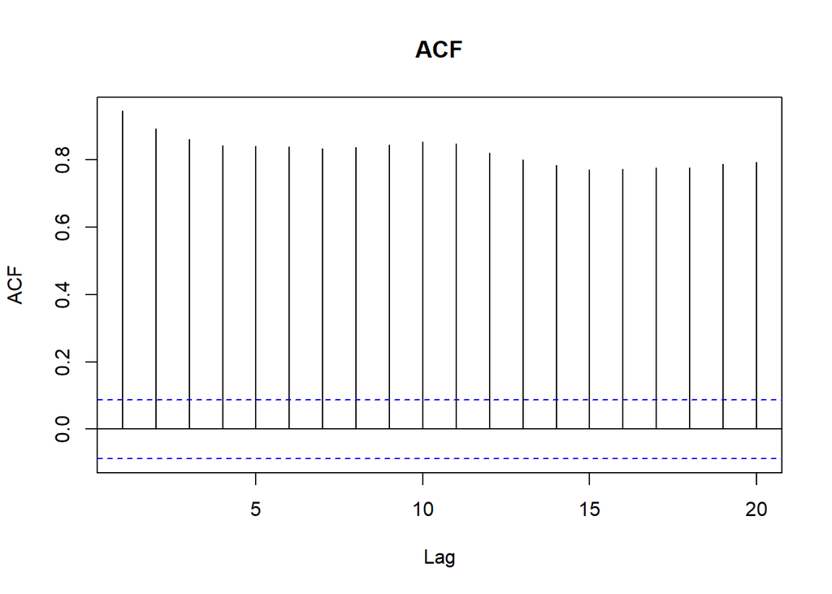

```r
acf(data.ts, main="ACF", lag.max=20)
```

Berdasarkan plot ACF di atas, dapat dilihat bahwa plot slowly cut off pada lag.

```r
adf.test(data.ts)
```

```
## Augmented Dickey-Fuller Test
## alternative: stationary
##
## Type 1: no drift no trend
##      lag   ADF p.value
## [1,]   0 0.325   0.737
## [2,]   1 0.385   0.755
## [3,]   2 0.462   0.777
## [4,]   3 0.533   0.797
## [5,]   4 0.567   0.807
## [6,]   5 0.638   0.827
## Type 2: with drift no trend
##      lag   ADF p.value
## [1,]   0 -3.41  0.0113
## [2,]   1 -3.42  0.0111
## [3,]   2 -2.84  0.0552
## [4,]   3 -2.34  0.1937
## [5,]   4 -1.78  0.4149
## [6,]   5 -1.65  0.4688
## Type 3: with drift and trend
##      lag   ADF p.value
## [1,]   0 -6.55  0.0100
## [2,]   1 -6.61  0.0100
## [3,]   2 -5.65  0.0100
## [4,]   3 -4.87  0.0100
## [5,]   4 -4.16  0.0100
## [6,]   5 -3.86  0.0153
## ----
## Note: in fact, p.value = 0.01 means p.value <= 0.01
```

H0 : Data tidak stasioner dalam rataan